# Lecture_08 - Intro to Machine Learning

Matt Demelo

4/25/2019

## K-means clustering

Let’s start off with an example run of the **kmeans()** function:

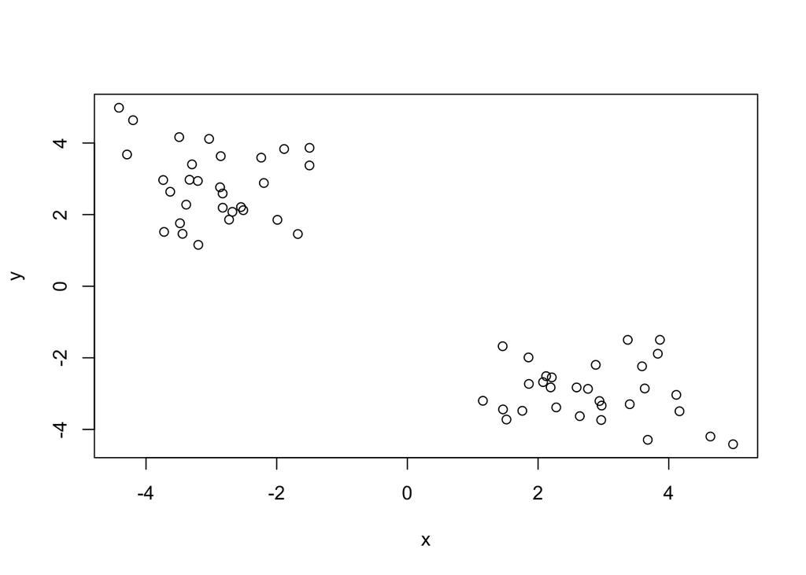

```r
# Generate some example data for clustering
tmp <- c(rnorm(30,-3), rnorm(30,3)) # 30 points centered on -3, 30 points center on +3
x <- cbind(x=tmp, y=rev(tmp)) # binds the two together as a matrix

plot(x)
```

Use the kmeans() function setting k to 2 and nstart=20 Inspect/print the results Q. How many points are in each cluster? *30 in each* Q. What ‘component’ of your result object details - cluster size? *“size”* – call x_clus$size - cluster assignment/membership? *"cluster"* call x_clus$cluster - cluster center? *“centers”* call x_clus$centers Plot x colored by the kmeans cluster assignment and add cluster centers as blue points

```r
x_clus <- kmeans(x, centers = 2, nstart = 20)
x_clus
```

```
## K-means clustering with 2 clusters of sizes 30, 30
##
## Cluster means:
##           x         y
## 1 -2.956305  2.832374
## 2  2.832374 -2.956305
##
## Clustering vector:
##  [1] 1 1 1 1 1 1 1 1 1 1 1 1 1 1 1 1 1 1 1 1 1 1 1 1 1 1 1 1 1 1 2 2 2 2 2
## [36] 2 2 2 2 2 2 2 2 2 2 2 2 2 2 2 2 2 2 2 2 2 2 2 2 2
##
## Within cluster sum of squares by cluster:
## [1] 47.69753 47.69753
##  (between_SS / total_SS =  91.3 %)
##
## Available components:
##
## [1] "cluster"      "centers"      "totss"        "withinss"
## [5] "tot.withinss" "betweenss"    "size"         "iter"
## [9] "ifault"
```

```r
x_clus$cluster
```

```
##  [1] 1 1 1 1 1 1 1 1 1 1 1 1 1 1 1 1 1 1 1 1 1 1 1 1 1 1 1 1 1 1 2 2 2 2 2
## [36] 2 2 2 2 2 2 2 2 2 2 2 2 2 2 2 2 2 2 2 2 2 2 2 2 2
```

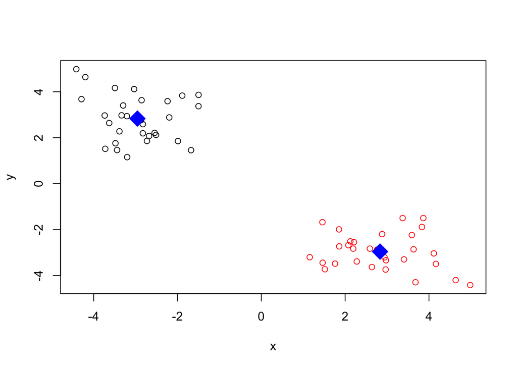

```r
plot(x, col = x_clus$cluster)
points(x_clus$centers, pch = 18, col = "blue", cex = 3)
```

## Hierarchical Clustering Example

Must give the **hclust()** function a distance matrix, not raw data, as an input.

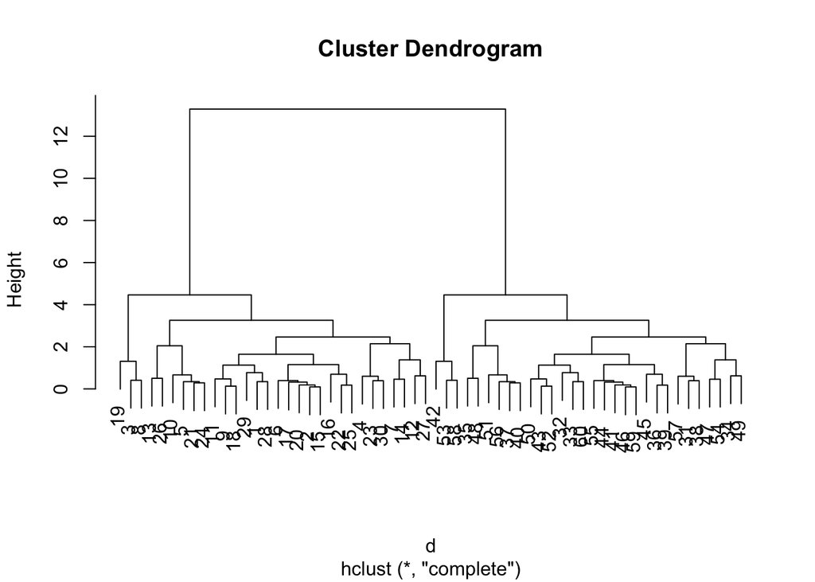

```r
# Distance matrix calc.
d <- dist(x)

# Clustering
hc <- hclust(d)
plot(hc)
```

This dendrogram makes sense: it starts from individual points, and begins clustering from there. It also shows us the structure of the data: which points lie in which groups, and so on. It is easy to visualzie that the points converge into two main groups

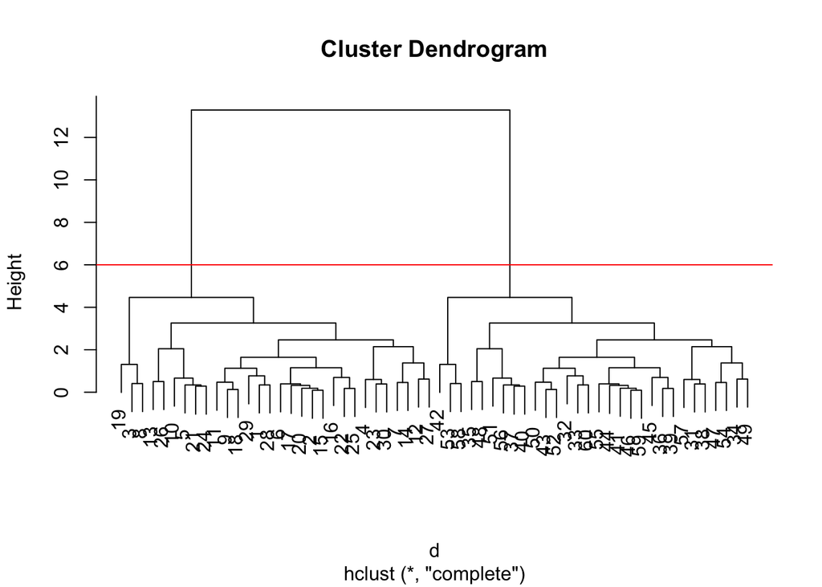

```r
plot(hc)
abline(h = 6, col = 2) # adds a height cutoff
```

```r
cutree(hc, h = 6) # groups clusters that fall below a height cut off, and returns a vector of clusters
```

```
##  [1] 1 1 1 1 1 1 1 1 1 1 1 1 1 1 1 1 1 1 1 1 1 1 1 1 1 1 1 1 1 1 2 2 2 2 2
## [36] 2 2 2 2 2 2 2 2 2 2 2 2 2 2 2 2 2 2 2 2 2 2 2 2 2
```

```r
cutree(hc, k = 2) # groups data into k# of clusters, and gives a vector output as well
```

```
##  [1] 1 1 1 1 1 1 1 1 1 1 1 1 1 1 1 1 1 1 1 1 1 1 1 1 1 1 1 1 1 1 2 2 2 2 2
## [36] 2 2 2 2 2 2 2 2 2 2 2 2 2 2 2 2 2 2 2 2 2 2 2 2 2
```

### Now with a more complicated dataset, with significant overlap.

```r
# Step 1. Generate some example data for clustering
x <- rbind(
 matrix(rnorm(100, mean=0, sd = 0.3), ncol = 2), # c1
 matrix(rnorm(100, mean = 1, sd = 0.3), ncol = 2), # c2
 matrix(c(rnorm(50, mean = 1, sd = 0.3), # c3
 rnorm(50, mean = 0, sd = 0.3)), ncol = 2))
colnames(x) <- c("x", "y")
```

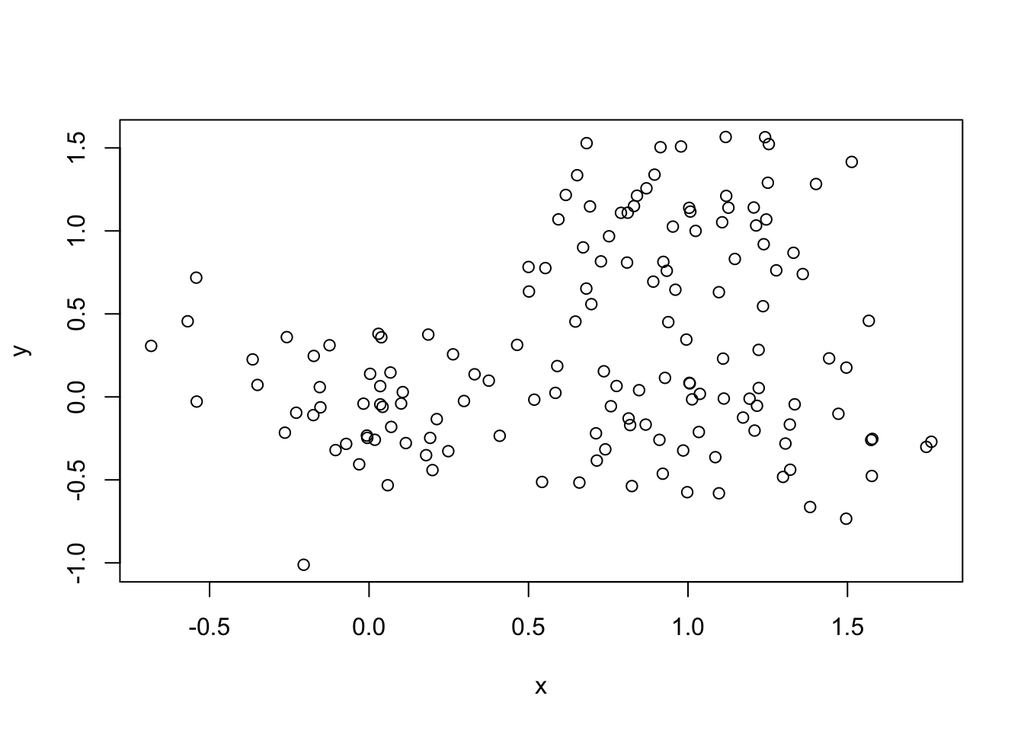

```r
# Step 2. Plot the data without clustering
plot(x)
```

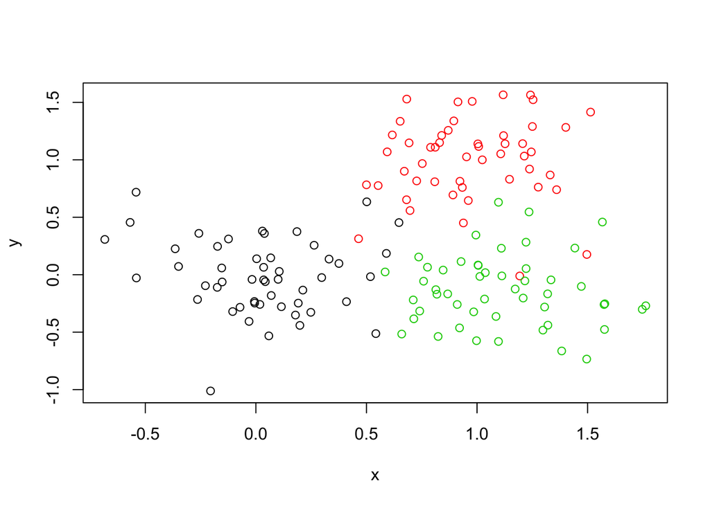

```r
# Step 3. Generate colors for known clusters
# (just so we can compare to hclust results)

col <- as.factor( rep(c("c1","c2","c3"), each=50) )

plot(x, col=col)
```

Q. Use the dist(), hclust(), plot() and cutree() functions to return 2 and 3 clusters Q. How does this compare to your known ‘col’ groups?

#### Now we use hclust to cluster the data hierarchically

```r
# *STEP 1*

# Converting x to distance data
xdist <- dist(x)

# Clustering of xdist, hierarchical
hier_x <- hclust(xdist)
hier_x
```

```
##
## Call:
## hclust(d = xdist)
##
## Cluster method   : complete
## Distance         : euclidean
## Number of objects: 150
```

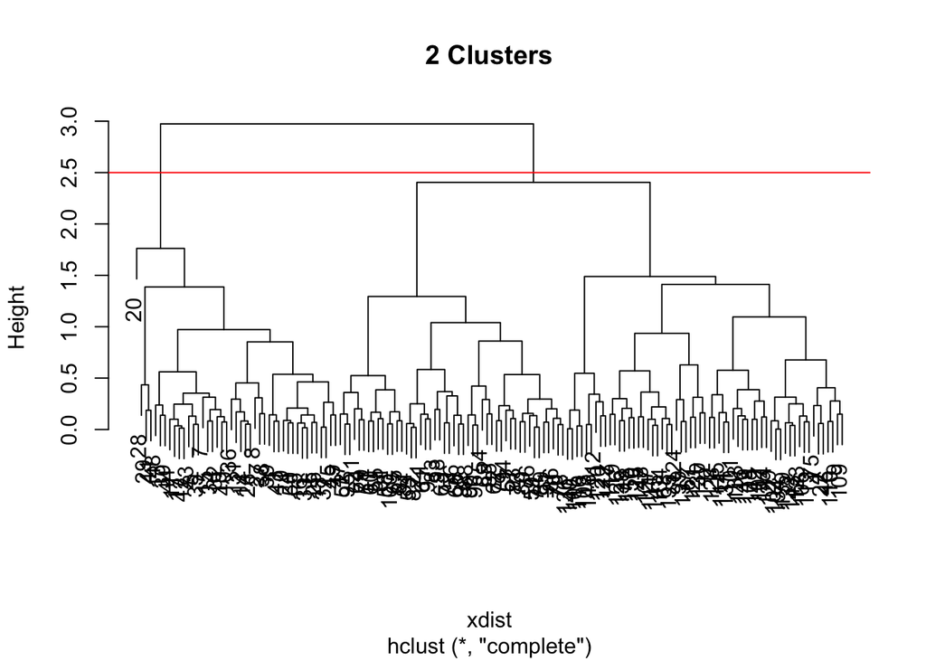

```r
# *STEP 2*

plot(hier_x, main = "2 Clusters")
abline(h = 2.5, col = 2)
```

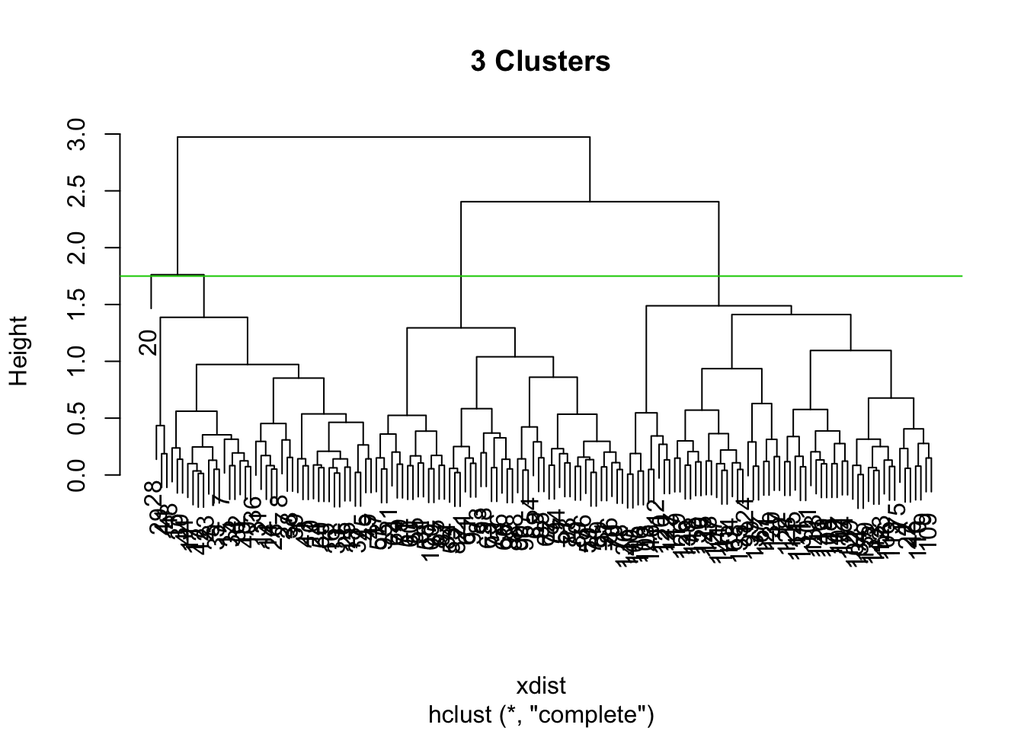

```r
plot(hier_x, main = "3 Clusters")
abline(h=1.75, col = 3)
```

```r
# *STEP 3.1*
gp2 <- cutree(hier_x, k = 2) # 2 clusters
gp2
```

```
##   [1] 1 2 1 2 1 1 1 1 2 1 1 1 1 1 1 1 1 1 1 1 2 2 1 1 1 1 1 1 1 1 1 1 1 1 1
##  [36] 1 1 1 1 1 1 1 1 1 1 2 2 1 1 1 2 2 2 2 2 2 2 2 2 2 2 2 2 2 2 2 2 2 2 2
##  [71] 2 2 2 2 2 2 2 2 2 2 2 2 2 2 2 2 2 2 2 2 2 2 2 2 2 2 2 2 2 2 2 2 2 2 2
## [106] 2 2 2 2 2 2 2 2 2 2 2 2 2 2 2 2 2 2 2 2 2 2 2 2 2 2 2 2 2 2 2 2 2 2 2
## [141] 2 2 2 2 2 2 2 2 2 2
```

```r
# *STEP 3.2*
gp3 <- cutree(hier_x, k = 3) # 2 clusters
gp3
```

```
##   [1] 1 2 1 2 1 1 1 1 2 1 1 1 1 1 1 1 1 1 1 1 3 2 1 1 1 1 1 1 1 1 1 1 1 1 1
##  [36] 1 1 1 1 1 1 1 1 1 1 2 3 1 1 1 3 3 3 3 3 3 3 3 3 3 3 3 3 3 3 3 2 2 3 3
##  [71] 3 3 3 3 2 3 3 3 3 3 3 3 3 3 3 3 3 3 3 3 3 3 3 3 3 3 3 3 2 3 2 2 2 2 2
## [106] 2 2 2 2 2 2 2 2 2 2 2 2 2 2 2 2 2 2 2 2 2 2 2 2 2 2 2 2 2 2 2 2 2 2 2
## [141] 2 2 2 2 2 2 2 2 2 2
```

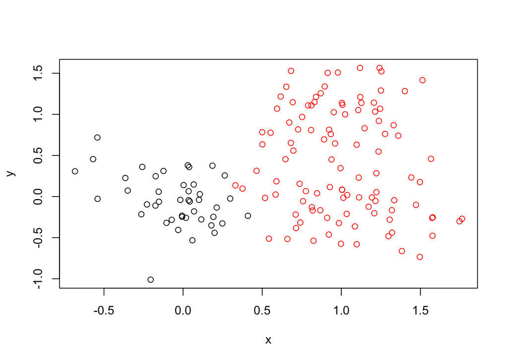

```r
plot(x, col = gp2)
```

The two-way clustering seems to be insufficient for clustering the data, so how about a three-way cluster?

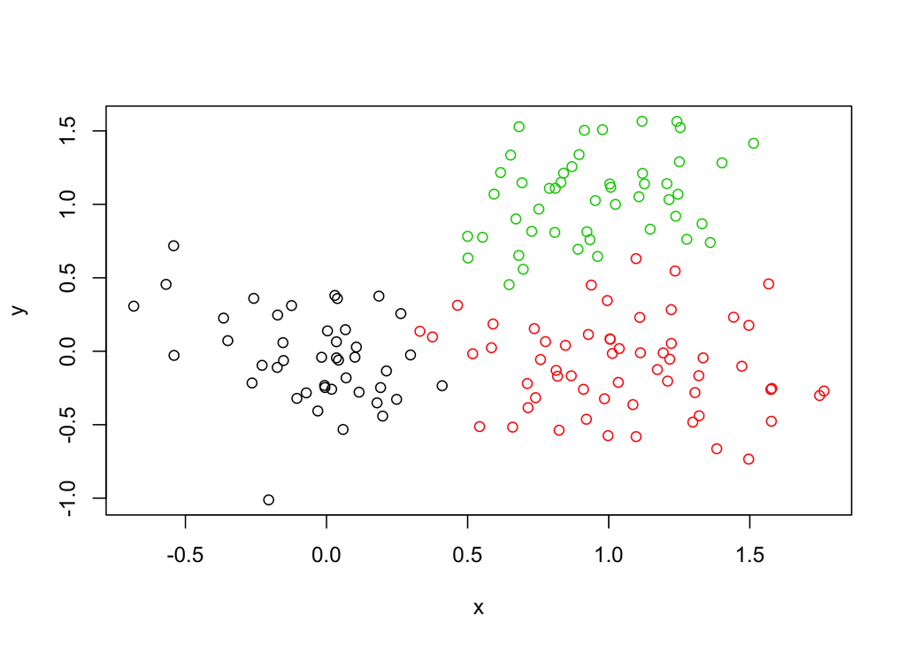

```r
plot(x, col = gp3)
```

The three way clustering isn’t perfect, but it’s a lot better than it was before we used hclust().

Let’s look at how many groups we have in each cluster:

```r
table(gp2)
```

```
## gp2
##   1   2
##  43 107
```

```r
table(gp3)
```

```
## gp3
##  1  2  3
## 43 59 48
```

What about a cross comparison?

```r
table(gp2, gp3)
```

```
##    gp3
## gp2  1  2  3
##   1 43  0  0
##   2  0 59 48
```